# ACTG175 Binary Harm Search: Simulation Study

- Show All Code
- Hide All Code
- View Source

**Setup and parameters (click to expand)**

```r
library(forestsearch)
library(speff2trial)
```

**Setup and parameters (click to expand)**

```r
library(data.table)
library(gt)
library(ggplot2)
library(doFuture)
```

**Setup and parameters (click to expand)**

```r
library(foreach)

set.seed(8316951L)

# -- Simulation control --------------------------------------------------------
nsims_alt   <- 5000L
nsims_null  <- 5000L
n_workers   <- max(1L, floor(0.95 * parallel::detectCores(logical = FALSE)))
sim_n       <- 1000L

# -- FS parameters -------------------------------------------------------------
c1 <- 1.25           # hr.threshold (OR scale)
c2 <- 1.0            # hr.consistency
fs_pconsistency    <- 0.80
max_look <- 5
fs_splits          <- 1000L
fs_n_min           <- 60L
fs_d0_min          <- 10L
fs_d1_min          <- 0L
fs_maxk            <- 2L
fs_dmin_grf        <- 0.0
fs_seedit          <- 8316951L
fs_sg_focus        <- "maxSG"
fs_use_lasso       <- FALSE
fs_use_grf         <- TRUE
fs_return_selected_cuts_only <- TRUE
fs_is_rct          <- TRUE

# -- GRF standalone parameters ------------------------------------------------
grf_dmin           <- 0.10
grf_maxdepth       <- 2L
grf_sg_criterion   <- "mDiff"

# -- Reporting -----------------------------------------------------------------
sg_notation        <- "harm"

# -- Calibration ---------------------------------------------------------------
cal_target_or      <- 2.0

# -- Diagnostic capture --------------------------------------------------------
diag_keep          <- c("fs_full", "candidate_table")
diag_keep_first_n  <- 5L

# -- Plot thresholds -----------------------------------------------------------
sgdist_min_pct_alt  <- 1
sgdist_min_pct_null <- 1
sgdist_top_k        <- 10L
ordist_ylim         <- c(0, 3)

# -- Consolidated parameter lists (used for both single-trial and sims) -------
# fs_params: passed to do.call(forestsearch, ...) for single-trial analyses
# and to run_simulation_analysis(fs_params = ...) for the simulation loop.
# run_simulation_analysis() overrides details/quiet internally.
# conf_force is set after data prep (depends on actg_df factor variables).
fs_params <- list(
  outcome.name           = "y_sim",
  event.name             = "y_sim",
  treat.name             = "treat_sim",
  id.name                = "id",
  outcome_type           = "binary",
  effect_measure         = "OR",
  use_lasso              = fs_use_lasso,
  use_grf                = fs_use_grf,
  return_selected_cuts_only = fs_return_selected_cuts_only,
  max_subgroups_search   = max_look,
  use_twostage           = TRUE,
  hr.threshold           = c1,
  hr.consistency         = c2,
  pconsistency.threshold = fs_pconsistency,
  stop_threshold         = 0.90,
  sg_focus               = fs_sg_focus,
  fs.splits              = fs_splits,
  n.min                  = fs_n_min,
  d0.min                 = fs_d0_min,
  d1.min                 = fs_d1_min,
  maxk                   = fs_maxk,
  dmin.grf               = fs_dmin_grf,
  is.RCT                 = fs_is_rct,
  seedit                 = fs_seedit,
  showten_subgroups      = FALSE,
  details                = TRUE,
  quiet                  = FALSE,
  parallel_args          = list(plan = "sequential", workers = 1,
                                show_message = FALSE)
)

grf_params <- list(
  dmin.grf     = grf_dmin,
  maxdepth     = grf_maxdepth,
  sg.criterion = grf_sg_criterion
)
```

# 1 Data Preparation

**ACTG175 data prep (click to expand)**

```r
# ACTG175: arm 1 = ZDV+ddI (experimental), arm 3 = ddI (control)
actg_df <- subset(speff2trial::ACTG175, arms %in% c(1L, 3L))
actg_df$id <- seq_len(nrow(actg_df))

# Treatment: ZDV+ddI = 1, ddI = 0 (NO switching)
actg_df$treat <- ifelse(actg_df$arms == 1L, 1L, 0L)

# Binary outcome: adverse (failure to improve)
actg_df$y_binary <- as.integer(actg_df$cd420 <= actg_df$cd40)
actg_df <- actg_df[!is.na(actg_df$cd420), ]

# -- DGM factor variables -----------------------------------------------------
# z1, z2: TRUE subgroup Q = {cd40 > 421 & wtkg > 82.3}
# (from observed-data FS result — see companion analysis document)

 actg_df$z1  <- as.factor(ifelse(actg_df$cd40 > 375, 1L, 0L))
 actg_df$z2  <- as.factor(ifelse(actg_df$wtkg > 75, 1L, 0L))

#actg_df$z1  <- as.factor(ifelse(actg_df$age > 34, 1L, 0L))
#actg_df$z2  <- as.factor(ifelse(actg_df$preanti <= 750, 1L, 0L))


# z7-z12: truly binary indicators (no continuous counterpart)
actg_df$z7  <- as.factor(actg_df$hemo)
actg_df$z8  <- as.factor(actg_df$homo)
actg_df$z9  <- as.factor(actg_df$drugs)
actg_df$z10 <- as.factor(actg_df$race)
actg_df$z11 <- as.factor(actg_df$gender)
actg_df$z12 <- as.factor(actg_df$symptom)

actg_df$ar_naive   <- as.factor(ifelse(actg_df$str2 == 0, 1L, 0L))
actg_df$prior_6mo  <- as.factor(ifelse(actg_df$preanti <= 6 * 30.4375, 1L, 0L))

actg_df$flag_harm_ref <- as.integer(actg_df$z1 == 1 & actg_df$z2 == 1)

# -- Analysis covariates (what the analyst sees) -------------------------------
cont_vars <- c("age", "preanti", "wtkg", "karnof", "cd40", "cd80")
bin_vars  <- c("hemo", "homo", "drugs", "race", "gender", "symptom","ar_naive","prior_6mo")
for (v in bin_vars) actg_df[[v]] <- as.factor(actg_df[[v]])
confounders <- c(cont_vars, bin_vars)

fs_conf_force <- c("ar_naive == 1","prior_6mo == 1")

# Inject conf_force into the consolidated fs_params (defined in setup,
# but conf_force depends on data-prep factor variables)
fs_params$conf_force <- fs_conf_force

# -- DGM variable sets ---------------------------------------------------------
dgm_factor_vars   <- c("z1", "z2", paste0("z", 7:12))
dgm_cont_vars     <- cont_vars
dgm_subgroup_vars <- c("z1", "z2")
dgm_subgroup_cuts <- list(z1 = 1L, z2 = 1L)

# -- Summary -------------------------------------------------------------------
Q_n   <- sum(actg_df$flag_harm_ref)
Q_N   <- nrow(actg_df)
Q_pct <- 100 * Q_n / Q_N

cat(sprintf("N = %d, Q prevalence = %d / %d (%.1f%%)\n", Q_N, Q_n, Q_N, Q_pct))
```

```
N = 1083, Q prevalence = 212 / 1083 (19.6%)
```

**ACTG175 data prep (click to expand)**

```r
cat(sprintf("Adverse rate: overall=%.1f%%, ZDV+ddI=%.1f%%, ddI=%.1f%%\n",
    100 * mean(actg_df$y_binary),
    100 * mean(actg_df$y_binary[actg_df$treat == 1]),
    100 * mean(actg_df$y_binary[actg_df$treat == 0])))
```

```
Adverse rate: overall=39.7%, ZDV+ddI=34.7%, ddI=44.4%
```

# 2 DGM Calibration

Target: OR(Q) = 2 on the adverse scale. The DGM includes factor variables (for subgroup definition) and raw continuous covariates (for a richer prognostic baseline), consistent with the survival `generate_aft_dgm_flex()` design.

```r
dgm_calibrated <- calibrate_glm_interaction(
  data            = actg_df,
  factor_vars     = dgm_factor_vars,
  continuous_vars = dgm_cont_vars,
  outcome_var     = "y_binary",
  treatment_var   = "treat",
  target_effect   = cal_target_or,
  outcome_type    = "binary",
  effect_measure  = "OR",
  subgroup_vars   = dgm_subgroup_vars,
  subgroup_cuts   = dgm_subgroup_cuts,
  k_inter_range   = c(0, 3),
  grid_step       = 0.05,
  n_super         = 5000L,
  seed            = 8316951L,
  verbose         = TRUE
)
```

```
Calibrating: target OR = 2.000 (search target: 2.0000)
  Grid: 0.00 to 3.00 by 0.050 (61 values)
  Best: k_inter = 1.200 -> Effect(Q) = 1.9921 (search target: 2.0000)
=== generate_glm_dgm() ===
  outcome_type:   binary
  effect_measure: OR
  model:          alt
  k_inter:        1.200
  k_treat:        1.000
  n_super:        5000
  n observations: 1083
  factor vars:    8
  continuous vars: 6 (age, preanti, wtkg, karnof, cd40, cd80)

=== Subgroup Definitions ===
   z1 == 1
    Proportion in subgroup: 0.375
   z2 == 1
    Proportion in subgroup: 0.474

Overall subgroup (all conditions met):
  Size: 212 out of 1083
  Proportion: 0.196

Baseline GLM fit (no interaction):
  AIC: 1379.6
  Treatment coefficient: -0.4583 (OR = 0.632)
  Interaction shift (k_inter): 1.2000

=== DGM Summary ===
  Effect(Q):   1.9921  (OR)
  Effect(Qc):  0.6561  (OR)
  Effect(ITT): 0.8239  (OR)
  Subgroup prevalence: 19.7%

Calibration complete: k_inter = 1.200
  Effect(Q):   1.9921  (actual Y scale)
  Effect(Qc):  0.6561
  Effect(ITT): 0.8239
```

```r
cat(sprintf("\n  OR(Q):   %.3f (target: %.1f)\n",
    dgm_calibrated$hazard_ratios$harm_subgroup, cal_target_or))
```

```
  OR(Q):   1.992 (target: 2.0)
```

```r
cat(sprintf("  OR(Qc):  %.3f\n", dgm_calibrated$hazard_ratios$no_harm_subgroup))
```

```
  OR(Qc):  0.656
```

```r
cat(sprintf("  OR(ITT): %.3f\n", dgm_calibrated$hazard_ratios$overall))
```

```
  OR(ITT): 0.824
```

```r
dgm_null <- generate_glm_dgm(
  data            = actg_df,
  factor_vars     = dgm_factor_vars,
  continuous_vars = dgm_cont_vars,
  outcome_var     = "y_binary",
  treatment_var   = "treat",
  outcome_type    = "binary",
  subgroup_vars   = dgm_subgroup_vars,
  subgroup_cuts   = dgm_subgroup_cuts,
  model           = "null",
  n_super         = 5000L,
  seed            = 8316951L,
  verbose         = TRUE
)
```

```
=== generate_glm_dgm() ===
  outcome_type:   binary
  effect_measure: OR
  model:          null
  k_inter:        0.000
  k_treat:        1.000
  n_super:        5000
  n observations: 1083
  factor vars:    8
  continuous vars: 6 (age, preanti, wtkg, karnof, cd40, cd80)

=== Subgroup Definitions ===
   z1 == 1
    Proportion in subgroup: 0.375
   z2 == 1
    Proportion in subgroup: 0.474

Overall subgroup (all conditions met):
  Size: 212 out of 1083
  Proportion: 0.196

Baseline GLM fit (no interaction):
  AIC: 1379.6
  Treatment coefficient: -0.4583 (OR = 0.632)
  Interaction shift (k_inter): 0.0000 (null model: forced to 0)

=== DGM Summary ===
  Effect(Q):   NA  (OR)
  Effect(Qc):  0.6585  (OR)
  Effect(ITT): 0.6585  (OR)
  Subgroup prevalence: 0.0%
```

# 3 Single Trial Sanity Check

**Single simulated trial + FS analysis alt (click to expand)**

```r
df_sim <- simulate_from_glm_dgm(dgm_calibrated, n = sim_n, seed = 42)

itt_fit <- glm(y_sim ~ treat_sim, family = "binomial", data = df_sim)
itt_OR <- exp(coef(itt_fit)["treat_sim"])
itt_event <- with(df_sim,mean(y_sim))

fpr_c1 <- fpr_approx(effect_true = itt_OR, p_event = itt_event, n_min = 60, c1 = c1,
           n_confounders_cont = length(cont_vars), n_confounders_bin = length(bin_vars),
           effect_type = "ratio", n_eff = max_look)
```

```
============================================================
  ForestSearch FPR Approximation (screening stage)
============================================================

  True effect (H0):   0.876  (log = -0.132)
  Event rate (ctrl):  40.9%
  Event rate (trt):   37.8%  (implied by OR = 0.88)
  Min subgroup (n):   60  (~30 per arm)
  SE(log effect):     0.529

  Confounders:        6 continuous (x4 cuts) + 8 binary
  Single candidates:  32
  Pair candidates:    496  (maxk = 2)
  Total candidates:   528
  Effective tests:    5  (user-specified)

  Threshold   P(per candidate)   FPR (indep)   FPR (adj)
  ---------   ----------------   -----------   ---------
    1.25         25.1%             100.0%         76.4% <-- c1

  Note: Screening-stage only.  Consistency check (pconsistency)
  and bootstrap correction further reduce the operational FPR.
  Independence FPR is an upper bound; adjusted uses Sidak with
  effective tests = 5 (user-specified).
============================================================
```

**Single simulated trial + FS analysis alt (click to expand)**

```r
fs_single <- do.call(forestsearch, c(
  list(df.analysis = df_sim, confounders.name = confounders),
  fs_params
))
```

```
[forestsearch] Subgroup Identification Configuration
  Outcome type:   binary
  Effect measure: OR (Odds Ratio)
  Scale:          log (ratio)

  Screening:      OR >= 1.25 (log: 0.2231)
  Consistency:    OR >= 1.00 (log: 0.0000)
  Consistency rate threshold: 80%

  Interpretation:
    Candidates: subgroup OR >= 1.25
    Splits:     each split OR >= 1.00
```

```
  Search Alignment Diagnostic
```

```
  Outcome:    y_sim (binary)
```

```
  Treatment:  treat_sim
```

```
  Measure:    Odds Ratio (OR) -- estimator sees Y as-is (no flip)
```

```
  ForestSearch searches for:
    Subgroups where treat_sim increases P(y_sim=1)
    (OR >= threshold on the ORIGINAL outcome scale)
```

```
  Thresholds:
    Screening: OR >= 1.250 in the candidate subgroup
    Consistency: OR >= 1.000 in each bootstrap split
```

```
  Variable screening:
```

```
    LASSO: LASSO screening: DISABLED
```

```
    GRF:   GRF sees 1-y_sim (flipped for causal_forest).
    Positive CATE = treatment REDUCES y_sim = treatment HELPS.
```

```
  No alignment concerns detected.
```

```
Forced confounders: ar_naive == 1, prior_6mo == 1
GRF subgroup: cd40 <= 375 & age <= 47 & wtkg <= 69
GRF cuts identified: 3
  Cuts: cd40 <= 375, age <= 47, wtkg <= 69
Candidate factors: 35
 [1] "cd40 <= 375"      "age <= 47"        "wtkg <= 69"       "age <= 35.7"
 [5] "age <= 35"        "age <= 30"        "age <= 40"        "preanti <= 373.3"
 [9] "preanti <= 114.5" "preanti <= 0"     "preanti <= 741"   "wtkg <= 75.2"
[13] "wtkg <= 74.5"     "wtkg <= 66.7"     "wtkg <= 82.6"     "karnof <= 95.1"
[17] "karnof <= 90"     "cd40 <= 349.6"    "cd40 <= 337.5"    "cd40 <= 260"
[21] "cd40 <= 421"      "cd80 <= 956.1"    "cd80 <= 895.5"    "cd80 <= 639"
[25] "cd80 <= 1170"     "hemo"             "homo"             "drugs"
[29] "race"             "gender"           "symptom"          "ar_naive"
[33] "prior_6mo"        "ar_naive == 1"    "prior_6mo == 1"
Number of possible configurations (<= maxk): maxk = 2 , # combinations = 2485
Per-arm events criteria: control >= 10, treatment >= 0
Sample size criteria: n >= 60
Subgroup search completed in 0.03 minutes

--- Filtering Summary ---
  Combinations evaluated: 2485
  Passed variance check: 2378
  Passed prevalence (>= 0.025 ): 2378
  Passed redundancy check: 2304
  Passed events counts (d0>= 10, d1>= 0): 2163
  Passed sample size (n>= 60 ): 2097
  GLM model fit successfully: 2097
  Passed effect threshold (OR >= 1.250): 217
-------------------------

Found 217 subgroup candidate(s)
# of candidate subgroups (meeting all criteria) = 217
Removed 48 near-duplicate subgroups
# of unique initial candidates: 169
# Restricting to top stop_Kgroups = 5
# of candidates to evaluate: 5
# Early stop threshold: 0.9
Parallel config: workers = 1 , batch_size = 1
Batch 1 / 5 : candidates 1 - 1

==================================================
EARLY STOP TRIGGERED (batch 1 )
  Candidate: 1 of 5
  Pcons: 0.92 >= 0.9
==================================================

Evaluated 1 of 5 candidates (early stop)
1 subgroups passed consistency threshold
SG focus = maxSG
Seconds and minutes forestsearch overall = 2.793 0.0466
Consistency algorithm used: twostage
Subgroup identified: !{race} & !{cd40 <= 260}
```

**Single simulated trial + FS analysis alt (click to expand)**

```r
if(!is.null(fs_single$sg.harm)){
fs_single_tabs <- sg_tables(fs_single, ndecimals = 3)
fs_single_tabs$sg10_out
fs_single_tabs$tab_estimates
}
```

**Treatment Effect Estimates**

Training data estimates

| Subgroup | n | n1 | Rate(C) | Rate(T) | Diff | OR (95% CI) |
| --- | --- | --- | --- | --- | --- | --- |
| ITT | 1000 (100.0%) | 528 (52.8%) | 42.6% | 39.4% | -3.2% | 0.88 (0.68, 1.13) |
| Questionable<sup>1</sup> | 534 (53.4%) | 286 (53.6%) | 39.5% | 46.9% | +7.3% | 1.35 (0.96, 1.90) |
| Recommend | 466 (46.6%) | 242 (51.9%) | 46.0% | 30.6% | -15.4% | 0.52 (0.35, 0.76) |

<sup>1</sup> **Identified subgroup:** !{race} & !{cd40 <= 260}

**Single simulated trial + FS analysis null (click to expand)**

```r
df_sim <- simulate_from_glm_dgm(dgm_null, n = sim_n, seed = 42)

itt_fit <- glm(y_sim ~ treat_sim, family = "binomial", data = df_sim)
itt_OR <- exp(coef(itt_fit)["treat_sim"])
itt_event <- with(df_sim,mean(y_sim))


fpr_c1 <- fpr_approx(effect_true = itt_OR, p_event = itt_event, n_min = 60, c1 = 1.25,
           n_confounders_cont = length(cont_vars), n_confounders_bin = length(bin_vars),
           effect_type = "ratio", n_eff = max_look)
```

```
============================================================
  ForestSearch FPR Approximation (screening stage)
============================================================

  True effect (H0):   0.674  (log = -0.394)
  Event rate (ctrl):  37.7%
  Event rate (trt):   29.0%  (implied by OR = 0.67)
  Min subgroup (n):   60  (~30 per arm)
  SE(log effect):     0.551

  Confounders:        6 continuous (x4 cuts) + 8 binary
  Single candidates:  32
  Pair candidates:    496  (maxk = 2)
  Total candidates:   528
  Effective tests:    5  (user-specified)

  Threshold   P(per candidate)   FPR (indep)   FPR (adj)
  ---------   ----------------   -----------   ---------
    1.25         13.1%             100.0%         50.5% <-- c1

  Note: Screening-stage only.  Consistency check (pconsistency)
  and bootstrap correction further reduce the operational FPR.
  Independence FPR is an upper bound; adjusted uses Sidak with
  effective tests = 5 (user-specified).
============================================================
```

**Single simulated trial + FS analysis null (click to expand)**

```r
fs_single <- do.call(forestsearch, c(
  list(df.analysis = df_sim, confounders.name = confounders),
  fs_params
))
```

```
[forestsearch] Subgroup Identification Configuration
  Outcome type:   binary
  Effect measure: OR (Odds Ratio)
  Scale:          log (ratio)

  Screening:      OR >= 1.25 (log: 0.2231)
  Consistency:    OR >= 1.00 (log: 0.0000)
  Consistency rate threshold: 80%

  Interpretation:
    Candidates: subgroup OR >= 1.25
    Splits:     each split OR >= 1.00
```

```
  Search Alignment Diagnostic
```

```
  Outcome:    y_sim (binary)
```

```
  Treatment:  treat_sim
```

```
  Measure:    Odds Ratio (OR) -- estimator sees Y as-is (no flip)
```

```
  ForestSearch searches for:
    Subgroups where treat_sim increases P(y_sim=1)
    (OR >= threshold on the ORIGINAL outcome scale)
```

```
  Thresholds:
    Screening: OR >= 1.250 in the candidate subgroup
    Consistency: OR >= 1.000 in each bootstrap split
```

```
  Variable screening:
```

```
    LASSO: LASSO screening: DISABLED
```

```
    GRF:   GRF sees 1-y_sim (flipped for causal_forest).
    Positive CATE = treatment REDUCES y_sim = treatment HELPS.
```

```
  No alignment concerns detected.
```

```
Forced confounders: ar_naive == 1, prior_6mo == 1
GRF subgroup: cd40 <= 396 & age <= 47 & cd40 <= 418
GRF cuts identified: 3
  Cuts: cd40 <= 396, cd40 <= 418, age <= 47
Candidate factors: 35
 [1] "cd40 <= 396"      "cd40 <= 418"      "age <= 47"        "age <= 35.7"
 [5] "age <= 35"        "age <= 30"        "age <= 40"        "preanti <= 373.3"
 [9] "preanti <= 114.5" "preanti <= 0"     "preanti <= 741"   "wtkg <= 75.2"
[13] "wtkg <= 74.5"     "wtkg <= 66.7"     "wtkg <= 82.6"     "karnof <= 95.1"
[17] "karnof <= 90"     "cd40 <= 349.6"    "cd40 <= 337.5"    "cd40 <= 260"
[21] "cd40 <= 421"      "cd80 <= 956.1"    "cd80 <= 895.5"    "cd80 <= 639"
[25] "cd80 <= 1170"     "hemo"             "homo"             "drugs"
[29] "race"             "gender"           "symptom"          "ar_naive"
[33] "prior_6mo"        "ar_naive == 1"    "prior_6mo == 1"
Number of possible configurations (<= maxk): maxk = 2 , # combinations = 2485
Per-arm events criteria: control >= 10, treatment >= 0
Sample size criteria: n >= 60
Subgroup search completed in 0.03 minutes

--- Filtering Summary ---
  Combinations evaluated: 2485
  Passed variance check: 2377
  Passed prevalence (>= 0.025 ): 2377
  Passed redundancy check: 2302
  Passed events counts (d0>= 10, d1>= 0): 2155
  Passed sample size (n>= 60 ): 2087
  GLM model fit successfully: 2087
  Passed effect threshold (OR >= 1.250): 10
-------------------------

Found 10 subgroup candidate(s)
# of candidate subgroups (meeting all criteria) = 10
Removed 2 near-duplicate subgroups
# of unique initial candidates: 8
# Restricting to top stop_Kgroups = 5
# of candidates to evaluate: 5
# Early stop threshold: 0.9
Parallel config: workers = 1 , batch_size = 1
Batch 1 / 5 : candidates 1 - 1
Batch 2 / 5 : candidates 2 - 2
Batch 3 / 5 : candidates 3 - 3
Batch 4 / 5 : candidates 4 - 4
Batch 5 / 5 : candidates 5 - 5
Evaluated 5 of 5 candidates (complete)
No subgroups found meeting consistency threshold
Seconds and minutes forestsearch overall = 3.93 0.0655
Consistency algorithm used: twostage
```

**Single simulated trial + FS analysis null (click to expand)**

```r
if(!is.null(fs_single$sg.harm)){
fs_single_tabs <- sg_tables(fs_single, ndecimals = 3)
fs_single_tabs$sg10_out
fs_single_tabs$tab_estimates
}
```

# 4 Full Simulation Study

## 4.1 Parameter Lists

**Parallel plan setup (click to expand)**

```r
plan(multisession, workers = n_workers)
cat("Using", n_workers, "parallel workers\n")
```

```
Using 13 parallel workers
```

**Parallel plan setup (click to expand)**

```r
cat("fs_params and grf_params defined in setup chunk\n")
```

```
fs_params and grf_params defined in setup chunk
```

## 4.2 H1 Simulations (Calibrated HTE)

**H1 simulation loop (click to expand)**

```r
cat("Running", nsims_alt, "simulations under H1...\n")
t0 <- proc.time()[3]

results_alt_raw <- foreach(
  sim = seq_len(nsims_alt),
  .errorhandling = "pass",
  .options.future = list(
    packages = c("forestsearch", "survival", "data.table", "future"),
    seed = TRUE
  )
) %dofuture% {
  future::plan("sequential")
  run_simulation_analysis(
    sim_id           = sim,
    dgm              = dgm_calibrated,
    n_sample         = sim_n,
    confounders_base = confounders,
    run_fs           = TRUE,
    run_fs_grf       = FALSE,
    run_grf          = TRUE,
    fs_params        = fs_params,
    grf_params       = grf_params,
    keep             = diag_keep,
    keep_first_n     = diag_keep_first_n,
    verbose          = FALSE
  )
}

t_alt <- proc.time()[3] - t0
results_alt <- collect_results(results_alt_raw, "H1 alt",
                               keep_diagnostics = diag_keep_first_n > 0L)
n_failed_alt <- attr(results_alt, "n_failed")

cat(sprintf("Completed in %.1f min (%d rows, %d failed)\n",
    t_alt / 60, nrow(results_alt), n_failed_alt))
```

## 4.3 H0 Simulations (Null — Homogeneous Effect)

**H0 simulation loop (click to expand)**

```r
cat("Running", nsims_null, "simulations under H0...\n")
t0 <- proc.time()[3]

results_null_raw <- foreach(
  sim = seq_len(nsims_null),
  .errorhandling = "pass",
  .options.future = list(
    packages = c("forestsearch", "survival", "data.table", "future"),
    seed = TRUE
  )
) %dofuture% {
  future::plan("sequential")
  run_simulation_analysis(
    sim_id           = sim,
    dgm              = dgm_null,
    n_sample         = sim_n,
    confounders_base = confounders,
    run_fs           = TRUE,
    run_fs_grf       = FALSE,
    run_grf          = TRUE,
    fs_params        = fs_params,
    grf_params       = grf_params,
    verbose          = FALSE
  )
}

t_null <- proc.time()[3] - t0
results_null <- collect_results(results_null_raw, "H0 null")
n_failed_null <- attr(results_null, "n_failed")

cat(sprintf("Completed in %.1f min (%d rows, %d failed)\n",
    t_null / 60, nrow(results_null), n_failed_null))
```

# 5 Results

## 5.1 Metrics Glossary

Classification metrics follow the definitions in León et al. (2024, Section 3).

### 5.1.1 Detection

**Found** ($\text{any}(Q)$): proportion of simulations where the method identifies *any* harm subgroup ($\texttt{any.H} = 1$).

- **Under H1** (alternative): $Q$ exists with a differential treatment effect. $\text{any}(Q)$ is **detection power**.
- **Under H0** (null): $Q = \emptyset$ and $Q^c$ is the ITT population. $\text{any}(Q)$ is the **false positive rate (FPR)** for falsely declaring that a harm subgroup exists.

### 5.1.2 Classification Under H1

$$\text{sens}(\hat{Q}) = \frac{\#\{i \in \hat{Q} \cap Q\}}{\#\{i \in Q\}},
\quad
\text{ppv}(\hat{Q}) = \frac{\#\{i \in \hat{Q} \cap Q\}}{\#\{i \in \hat{Q}\}},$$

with analogous measures for the complement $\hat{Q}^c$.

The operating-characteristics tables report these as:

| Table column | León et al. notation | Interpretation |
| --- | --- | --- |
| **Sen** | $\text{sens}(\hat{Q})$ | Fraction of true $Q$ captured by $\hat{Q}$ |
| **Spec** | $\text{sens}(\hat{Q}^c)$ | Fraction of true $Q^c$ correctly in $\hat{Q}^c$ |
| **PPV** | $\text{ppv}(\hat{Q})$ | Fraction of $\hat{Q}$ truly in $Q$ |
| **NPV** | $\text{ppv}(\hat{Q}^c)$ | Fraction of $\hat{Q}^c$ truly in $Q^c$ |

Classification metrics are averaged across **all** simulations (León et al. 2024, Table 1). When no subgroup is detected ($\hat{Q} = \emptyset$), the simulation contributes $\text{sens}(\hat{Q}) = 0$ and $\text{ppv}(\hat{Q}) = 0$ (since no member of $Q$ is captured and no subjects are assigned to $\hat{Q}$). This convention is implemented at the source in `run_simulation_analysis()`, matching the original `fs.estimates.out()` function used in León et al. (2024).

**NoteClassification metrics with discovered cuts**

### 5.1.3 Classification Under H0

Under the null, $Q = \emptyset$ — no subgroup with a differential treatment effect exists. The complement $Q^c$ is the entire ITT population. Per León et al. (2024, Section 3), $\text{sens}(\hat{Q})$ is **undefined** (shown as “—” in the table) and $\text{ppv}(\hat{Q}) \equiv 0$. For the complement, $\text{sens}(\hat{Q}^c) = |\hat{Q}^c|/N$ and $\text{ppv}(\hat{Q}^c) = 1$ since $Q^c$ = ITT.

The only operationally meaningful metric under H0 is the **detection rate (FPR)**.

### 5.1.4 Effect Estimates

All effect estimates are on the adverse scale: OR $> 1$ = treatment (ZDV+ddI) increases the adverse outcome (non-improvement) = **harm**. No inversion or treatment switching is applied.

# 6 Operating Characteristics

## 6.1 H1: Detection + Classification

```r
format_oc_results(
  results_alt,
  metrics   = c("detection", "classification", "subgroup_size"),
  digits    = 2,
  digits_hr = 2,
  title     = "ACTG175 Binary: Harm Subgroup Identification",
  subtitle  = sprintf(
    "n = %d, %d sims, OR(Q) = %.2f, OR(Qc) = %.2f",
    sim_n, nsims_alt,
    dgm_calibrated$hazard_ratios$harm_subgroup,
    dgm_calibrated$hazard_ratios$no_harm_subgroup
  ),
  subgroup_notation = sg_notation
)
```

ACTG175 Binary: Harm Subgroup Identification

n = 1000, 5000 sims, OR(Q) = 1.99, OR(Qc) = 0.66

[output not shown]

### 6.1.1 True Subgroup Sizes Across Replicates

```r
# One row per replicate-method combination, but sizeH_true is identical
# across method rows within the same sim.  Deduplicate on sim.
truth_by_sim <- unique(results_alt[, c("sim", "sizeH_true", "sizeHc_true",
                                        "propH_true", "propHc_true")])

callout_Q <- sprintf(
  "|Q|:  mean = %.1f (SD %.2f),  range = [%d, %d],  prop = %.1f%%",
  mean(truth_by_sim$sizeH_true),
  sd(truth_by_sim$sizeH_true),
  min(truth_by_sim$sizeH_true),
  max(truth_by_sim$sizeH_true),
  100 * mean(truth_by_sim$propH_true))

callout_Qc <- sprintf(
  "|Qc|: mean = %.1f (SD %.2f),  range = [%d, %d],  prop = %.1f%%",
  mean(truth_by_sim$sizeHc_true),
  sd(truth_by_sim$sizeHc_true),
  min(truth_by_sim$sizeHc_true),
  max(truth_by_sim$sizeHc_true),
  100 * mean(truth_by_sim$propHc_true))

cat(sprintf("True subgroup sizes across %d H1 replicates (N = %d each):\n",
            nrow(truth_by_sim), sim_n))
```

```
True subgroup sizes across 5000 H1 replicates (N = 1000 each):
```

```r
cat("  ", callout_Q,  "\n")
```

```
   |Q|:  mean = 196.8 (SD 12.45),  range = [156, 252],  prop = 19.7%
```

```r
cat("  ", callout_Qc, "\n")
```

```
   |Qc|: mean = 803.2 (SD 12.45),  range = [748, 844],  prop = 80.3%
```

**NoteReference sizes for the estimation tables below**

- **|Q| (true harm subgroup)**: mean 196.8 per trial (SD 12.45, range 156–252, average proportion 19.7%).
- **|Qc| (complement)**: mean 803.2 per trial (SD 12.45, range 748–844, average proportion 80.3%).

Compare to $\widehat{|H|}$ (the FS-identified subgroup size) reported in the row-group labels of the estimation tables below. A ratio $\widehat{|H|} \big/ \overline{|Q|} \approx 1$ indicates the method is recovering a subgroup close to the true size; values much smaller suggest FS is identifying a strict subset of $Q$; values larger suggest FS is absorbing some $Q^c$ subjects into $\hat H$.

## 6.2 H1: Estimation Tables

```r
build_estimation_table(
  results         = results_alt,
  dgm             = dgm_calibrated,
  analysis_method = "FS",
  subgroup_notation = sg_notation,
  title           = "FS: Effect Estimates Under H1"
)
```

FS: Effect Estimates Under H1

FS: 4487/5000 (90%) estimable

|  | Avg | SD | Min | Max | b‡ (%) | b† (%) |
| --- | --- | --- | --- | --- | --- | --- |
| Ĥ: 4487 estimable, avg \|Ĥ\| = 425, θ†(H) = 1.99, θ‡(H) = 2.1 |  |  |  |  |  |  |
| θ̂(Ĥ) | 1.36 | 0.11 | 1.25 | 2.71 | -35.02 | -31.52 |
| âhr(Ĥ) | 1.03 | 0.19 | 0.64 | 2.01 | NA | -48.34 |
| θ‡(Ĥ) | 1.34 | 0.23 | 0.63 | 2.10 | NA | -36.38 |
| Ĥᶜ: avg \|Ĥᶜ\| = 575, θ†(Hᶜ) = 0.66, θ‡(Hᶜ) = 0.63 |  |  |  |  |  |  |
| θ̂(Ĥᶜ) | 0.58 | 0.09 | 0.28 | 1.12 | -7.78 | -11.12 |
| âhr(Ĥᶜ) | 0.71 | 0.06 | 0.64 | 1.12 | NA | 8.75 |
| θ‡(Ĥᶜ) | 0.79 | 0.16 | 0.63 | 1.68 | NA | 25.26 |

θ̂(Ĥ) = plugin OR estimate in identified subgroup; θ̂*(Ĥ) = bootstrap bias-corrected; b† = bias relative to true OR θ† (causal truth); θ‡(Ĥ) = controlled direct effect in identified subgroup; b‡ = bias relative to CDE θ‡

```r
build_estimation_table(
  results         = results_alt,
  dgm             = dgm_calibrated,
  analysis_method = "GRF",
  subgroup_notation = sg_notation,
  title           = "GRF: Effect Estimates Under H1"
)
```

GRF: Effect Estimates Under H1

GRF: 4870/5000 (97%) estimable

|  | Avg | SD | Min | Max | b‡ (%) | b† (%) |
| --- | --- | --- | --- | --- | --- | --- |
| Ĥ: 4870 estimable, avg \|Ĥ\| = 318, θ†(H) = 1.99, θ‡(H) = 2.1 |  |  |  |  |  |  |
| θ̂(Ĥ) | 2.20 | 0.59 | 1.28 | 9.53 | 4.75 | 10.40 |
| âhr(Ĥ) | 1.13 | 0.22 | 0.64 | 1.92 | NA | -43.05 |
| θ‡(Ĥ) | 1.46 | 0.26 | 0.63 | 2.10 | NA | -30.58 |
| Ĥᶜ: avg \|Ĥᶜ\| = 682, θ†(Hᶜ) = 0.66, θ‡(Hᶜ) = 0.63 |  |  |  |  |  |  |
| θ̂(Ĥᶜ) | 0.53 | 0.08 | 0.25 | 0.86 | -16.67 | -19.68 |
| âhr(Ĥᶜ) | 0.71 | 0.06 | 0.65 | 0.89 | NA | 8.70 |
| θ‡(Ĥᶜ) | 0.79 | 0.14 | 0.63 | 1.23 | NA | 24.50 |

θ̂(Ĥ) = plugin OR estimate in identified subgroup; θ̂*(Ĥ) = bootstrap bias-corrected; b† = bias relative to true OR θ† (causal truth); θ‡(Ĥ) = controlled direct effect in identified subgroup; b‡ = bias relative to CDE θ‡

## 6.3 H1: Classification Tables

```r
scenario_alt <- list(
  H1 = list(
    results    = results_alt,
    dgm        = dgm_calibrated,
    hypothesis = "alt",
    n_sample   = sim_n,
    label      = "ACTG175"
  )
)

build_classification_table(
  scenario_alt,
  analyses          = "FS",
  subgroup_notation = sg_notation,
  title             = "FS: Classification Under H1"
)
```

FS: Classification Under H1

|  | FS |
| --- | --- |
| ACTG175 Alt: N=1000, p_H=20%, theta(H)=1.99, theta(Hc)=0.66, theta(ITT)=0.82 |  |
| any(H) | 0.90 |
| sens(H) | 0.71 |
| sens(Hc) | 0.68 |
| ppv(H) | 0.36 |
| ppv(Hc) | 0.94 |
| avg\|H\| | 425.00 |

```r
build_classification_table(
  scenario_alt,
  analyses          = "GRF",
  subgroup_notation = sg_notation,
  title             = "GRF: Classification Under H1"
)
```

GRF: Classification Under H1

|  | GRF |
| --- | --- |
| ACTG175 Alt: N=1000, p_H=20%, theta(H)=1.99, theta(Hc)=0.66, theta(ITT)=0.82 |  |
| any(H) | 0.97 |
| sens(H) | 0.73 |
| sens(Hc) | 0.79 |
| ppv(H) | 0.47 |
| ppv(Hc) | 0.93 |
| avg\|H\| | 318.00 |

## 6.4 H1: Subgroup Distribution

```r
plot_sg_distribution(
  results_alt[results_alt$analysis == "FS", ],
  any_col   = "any.H",
  label_col = "sg.def",
  min_pct   = sgdist_min_pct_alt,
  top_k     = sgdist_top_k,
  title     = "FS: Identified Subgroup Distribution (H1)"
)
```

```
No subgroup appears in ≥ 1% of found simulations.
```

## 6.5 H1: OR Distribution

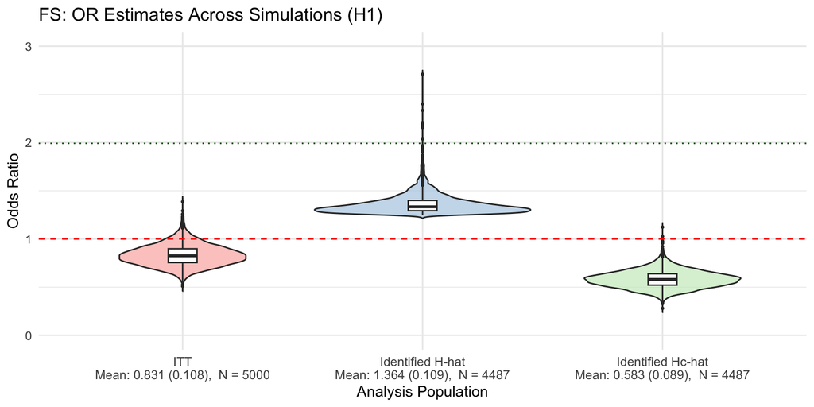

```r
or_Q_true <- dgm_calibrated$hazard_ratios$harm_subgroup

plot_effect_distribution(
  results           = results_alt,
  analysis_method   = "FS",
  effect_measure    = "OR",
  subgroup_notation = sg_notation,
  reference_effect  = or_Q_true,
  ylim              = ordist_ylim,
  title             = "FS: OR Estimates Across Simulations (H1)"
)
```

## 6.6 H0: Type I Error

```r
format_oc_results(
  results_null,
  dgm = dgm_null,
  metrics   = c("detection", "classification"),
  digits    = 2,
  title     = "ACTG175 Binary: Type I Error (Null)",
  subtitle  = sprintf(
    "n = %d, %d sims, OR(ITT) = %.2f",
    sim_n, nsims_null,
    dgm_null$hazard_ratios$overall
  ),
  subgroup_notation = sg_notation
)
```

ACTG175 Binary: Type I Error (Null)

n = 1000, 5000 sims, OR(ITT) = 0.66

| Method | Sims | Found | Classification Sen | Classification Spec | Classification PPV | Classification NPV |
| --- | --- | --- | --- | --- | --- | --- |
| FS | 5000 | 0.52 | - | 0.89 | 0.00 | 1.00 |
| GRF | 5000 | 0.94 | - | 0.84 | 0.00 | 1.00 |

## 6.7 H0: Estimation Tables

```r
build_estimation_table(
  results         = results_null,
  dgm             = dgm_null,
  analysis_method = "FS",
  subgroup_notation = sg_notation,
  title           = "FS: Effect Estimates Under H0"
)
```

FS: Effect Estimates Under H0

FS: 2615/5000 (52%) estimable

|  | Avg | SD | Min | Max | b‡ (%) | b† (%) |
| --- | --- | --- | --- | --- | --- | --- |
| Ĥ: 2615 estimable, avg \|Ĥ\| = 206, θ†(H) = 0.66, θ‡(H) = 0.63 |  |  |  |  |  |  |
| θ̂(Ĥ) | 1.64 | 0.28 | 1.25 | 4.34 | 159.59 | 149.30 |
| âhr(Ĥ) | 0.65 | 0.01 | 0.64 | 0.68 | NA | -0.77 |
| θ‡(Ĥ) | 0.63 | 0.00 | 0.63 | 0.63 | NA | 0.00 |
| Ĥᶜ: avg \|Ĥᶜ\| = 794, θ†(Hᶜ) = 0.66, θ‡(Hᶜ) = 0.63 |  |  |  |  |  |  |
| θ̂(Ĥᶜ) | 0.55 | 0.07 | 0.33 | 0.85 | -12.83 | -16.28 |
| âhr(Ĥᶜ) | 0.66 | 0.00 | 0.65 | 0.67 | NA | -0.11 |
| θ‡(Ĥᶜ) | 0.63 | 0.00 | 0.63 | 0.63 | NA | 0.00 |

θ̂(Ĥ) = plugin OR estimate in identified subgroup; θ̂*(Ĥ) = bootstrap bias-corrected; b† = bias relative to true OR θ† (causal truth); θ‡(Ĥ) = controlled direct effect in identified subgroup; b‡ = bias relative to CDE θ‡

```r
build_estimation_table(
  results         = results_null,
  dgm             = dgm_null,
  analysis_method = "GRF",
  subgroup_notation = sg_notation,
  title           = "GRF: Effect Estimates Under H0"
)
```

GRF: Effect Estimates Under H0

GRF: 4679/5000 (94%) estimable

|  | Avg | SD | Min | Max | b‡ (%) | b† (%) |
| --- | --- | --- | --- | --- | --- | --- |
| Ĥ: 4679 estimable, avg \|Ĥ\| = 175, θ†(H) = 0.66, θ‡(H) = 0.63 |  |  |  |  |  |  |
| θ̂(Ĥ) | 2.53 | 1.11 | 1.36 | 24.38 | 299.65 | 283.81 |
| âhr(Ĥ) | 0.66 | 0.01 | 0.64 | 0.71 | NA | 0.13 |
| θ‡(Ĥ) | 0.63 | 0.00 | 0.63 | 0.63 | NA | 0.00 |
| Ĥᶜ: avg \|Ĥᶜ\| = 825, θ†(Hᶜ) = 0.66, θ‡(Hᶜ) = 0.63 |  |  |  |  |  |  |
| θ̂(Ĥᶜ) | 0.51 | 0.07 | 0.32 | 0.86 | -18.76 | -21.98 |
| âhr(Ĥᶜ) | 0.66 | 0.00 | 0.65 | 0.67 | NA | -0.23 |
| θ‡(Ĥᶜ) | 0.63 | 0.00 | 0.63 | 0.63 | NA | 0.00 |

θ̂(Ĥ) = plugin OR estimate in identified subgroup; θ̂*(Ĥ) = bootstrap bias-corrected; b† = bias relative to true OR θ† (causal truth); θ‡(Ĥ) = controlled direct effect in identified subgroup; b‡ = bias relative to CDE θ‡

## 6.8 H0: Subgroup Distribution

```r
plot_sg_distribution(
  results_null[results_null$analysis == "FS", ],
  any_col   = "any.H",
  label_col = "sg.def",
  min_pct   = sgdist_min_pct_null,
  top_k     = sgdist_top_k,
  title     = "FS: Identified Subgroup Distribution (H0)"
)
```

```
No subgroup appears in ≥ 1% of found simulations.
```

# 7 Timing

```r
cat(sprintf("H1: %.1f min (%d sims)\n", t_alt / 60, nsims_alt))
```

```
H1: 69.2 min (5000 sims)
```

```r
cat(sprintf("H0: %.1f min (%d sims)\n", t_null / 60, nsims_null))
```

```
H0: 63.7 min (5000 sims)
```

```r
plan(sequential)
```